# Part I - Ford GoBike System Data Exploration

## Introduction

This project explores the Ford GoBike System dataset, which contains information about individual bike trips taken in the San Francisco Bay Area. The dataset includes features such as trip duration, start and end times, station locations, and user demographics.

The main objective of this analysis is to investigate patterns in bike usage and understand how different factors influence trip behavior.

Specifically, this analysis aims to explore how trip duration, time of day, user type, and demographic characteristics affect riding patterns.

The exploration will follow a structured approach, beginning with univariate analysis to understand individual variables, followed by bivariate and multivariate analysis to uncover relationships and deeper insights within the dataset.

> The following questions will guide the data exploration:
> 1. What is the distribution of trip durations?
> 2. What are the most popular periods to ride a bike?
> 3. Which days are most crowded for riding bikes?
> 4. How are the different kind of users distributed (customer vs. subscriber)?
> 5. How does the length of a trip vary depending on the time of day?
> 6. Does the length of a trip correlate with the user's age?
> 7. How does trip duration differ between Subscribers and Customers?
> 8. What interactions exist between various parameters (such as user type and time of day) that affect journey duration?
> 9. How does the length of a trip change depending on the time of day for various user types?
> 10. What differences exist between user types in the link between age and trip duration?
> 11. What is the relationship between average trip duration and user type and time of day?

## Preliminary Wrangling

```python
# import all packages and set plots to be embedded inline
import numpy as np
import pandas as pd
import matplotlib.pyplot as plt
import seaborn as sns

%matplotlib inline
```

```python
df = pd.read_csv("fordgobike-tripdata.csv")
df.head(5)
```

|  | duration_sec | start_time | end_time | start_station_id | start_station_name | start_station_latitude | start_station_longitude | end_station_id | end_station_name | end_station_latitude | end_station_longitude | bike_id | user_type | member_birth_year | member_gender | bike_share_for_all_trip |
| --- | --- | --- | --- | --- | --- | --- | --- | --- | --- | --- | --- | --- | --- | --- | --- | --- |
| 0 | 52185 | 2019-02-28 17:32:10.1450 | 2019-03-01 08:01:55.9750 | 21.0 | Montgomery St BART Station (Market St at 2nd St) | 37.789625 | -122.400811 | 13.0 | Commercial St at Montgomery St | 37.794231 | -122.402923 | 4902 | Customer | 1984.0 | Male | No |
| 1 | 42521 | 2019-02-28 18:53:21.7890 | 2019-03-01 06:42:03.0560 | 23.0 | The Embarcadero at Steuart St | 37.791464 | -122.391034 | 81.0 | Berry St at 4th St | 37.775880 | -122.393170 | 2535 | Customer | NaN | NaN | No |
| 2 | 61854 | 2019-02-28 12:13:13.2180 | 2019-03-01 05:24:08.1460 | 86.0 | Market St at Dolores St | 37.769305 | -122.426826 | 3.0 | Powell St BART Station (Market St at 4th St) | 37.786375 | -122.404904 | 5905 | Customer | 1972.0 | Male | No |
| 3 | 36490 | 2019-02-28 17:54:26.0100 | 2019-03-01 04:02:36.8420 | 375.0 | Grove St at Masonic Ave | 37.774836 | -122.446546 | 70.0 | Central Ave at Fell St | 37.773311 | -122.444293 | 6638 | Subscriber | 1989.0 | Other | No |
| 4 | 1585 | 2019-02-28 23:54:18.5490 | 2019-03-01 00:20:44.0740 | 7.0 | Frank H Ogawa Plaza | 37.804562 | -122.271738 | 222.0 | 10th Ave at E 15th St | 37.792714 | -122.248780 | 4898 | Subscriber | 1974.0 | Male | Yes |

```python
df.shape
```

```
(183412, 16)
```

```python
df.info()
```

```
<class 'pandas.core.frame.DataFrame'>
RangeIndex: 183412 entries, 0 to 183411
Data columns (total 16 columns):
 #   Column                   Non-Null Count   Dtype
---  ------                   --------------   -----
 0   duration_sec             183412 non-null  int64
 1   start_time               183412 non-null  object
 2   end_time                 183412 non-null  object
 3   start_station_id         183215 non-null  float64
 4   start_station_name       183215 non-null  object
 5   start_station_latitude   183412 non-null  float64
 6   start_station_longitude  183412 non-null  float64
 7   end_station_id           183215 non-null  float64
 8   end_station_name         183215 non-null  object
 9   end_station_latitude     183412 non-null  float64
 10  end_station_longitude    183412 non-null  float64
 11  bike_id                  183412 non-null  int64
 12  user_type                183412 non-null  object
 13  member_birth_year        175147 non-null  float64
 14  member_gender            175147 non-null  object
 15  bike_share_for_all_trip  183412 non-null  object
dtypes: float64(7), int64(2), object(7)
memory usage: 22.4+ MB
```

```python
df.describe()
```

|  | duration_sec | start_station_id | start_station_latitude | start_station_longitude | end_station_id | end_station_latitude | end_station_longitude | bike_id | member_birth_year |
| --- | --- | --- | --- | --- | --- | --- | --- | --- | --- |
| count | 183412.000000 | 183215.000000 | 183412.000000 | 183412.000000 | 183215.000000 | 183412.000000 | 183412.000000 | 183412.000000 | 175147.000000 |
| mean | 726.078435 | 138.590427 | 37.771223 | -122.352664 | 136.249123 | 37.771427 | -122.352250 | 4472.906375 | 1984.806437 |
| std | 1794.389780 | 111.778864 | 0.099581 | 0.117097 | 111.515131 | 0.099490 | 0.116673 | 1664.383394 | 10.116689 |
| min | 61.000000 | 3.000000 | 37.317298 | -122.453704 | 3.000000 | 37.317298 | -122.453704 | 11.000000 | 1878.000000 |
| 25% | 325.000000 | 47.000000 | 37.770083 | -122.412408 | 44.000000 | 37.770407 | -122.411726 | 3777.000000 | 1980.000000 |
| 50% | 514.000000 | 104.000000 | 37.780760 | -122.398285 | 100.000000 | 37.781010 | -122.398279 | 4958.000000 | 1987.000000 |
| 75% | 796.000000 | 239.000000 | 37.797280 | -122.286533 | 235.000000 | 37.797320 | -122.288045 | 5502.000000 | 1992.000000 |
| max | 85444.000000 | 398.000000 | 37.880222 | -121.874119 | 398.000000 | 37.880222 | -121.874119 | 6645.000000 | 2001.000000 |

#### What is the structure of your dataset?

> The dataset contains 183,412 records, where each row represents a single bike trip. It includes 16 features consisting of a mix of numerical and categorical variables. The numerical variables include trip duration, station coordinates, bike ID, and member birth year, while categorical variables include user type, gender, and bike-sharing status. Additionally, time-related variables such as start_time and end_time are currently stored as strings and will need to be converted into datetime format for proper analysis. Some features, such as station IDs, station names, member birth year, and gender, contain missing values, which will require handling during the data cleaning process.

#### What is/are the main feature(s) of interest in your dataset?

> The main feature of interest in this dataset is the trip duration (duration_sec), as it reflects user behavior and how the bike-sharing system is utilized. Additionally, user-related features such as user_type, member_gender, and member_birth_year (used to derive age) are of interest, as they can provide insights into how different groups of users behave. Time-related features derived from start_time, such as hour and day of the week, are also important for understanding usage patterns. The analysis will focus on identifying how these factors influence trip duration and overall bike usage.

### What features in the dataset do you think will help support your investigation into your feature(s) of interest?

- time-related variables (to extract hour, day, and month),
- user-related variables (such as user type, gender, and age),
- location-based features (start and end stations).

> Additionally, the bike_share_for_all_trip variable helps assess program participation. These features enable the analysis of usage patterns and relationships affecting trip duration.

## Data Cleaning

```python
# Convert datetime
df['start_time'] = pd.to_datetime(df['start_time'])
df['end_time'] = pd.to_datetime(df['end_time'])
```

```python
# Extract useful features
df['start_hour'] = df['start_time'].dt.hour
df['start_day'] = df['start_time'].dt.day_name()
df['start_month'] = df['start_time'].dt.month_name()
```

```python
# Create age column
df['age'] = df['start_time'].dt.year - df['member_birth_year']
```

```python
# Remove outliers
df = df[df['duration_sec'] < 3600]  # remove trips longer than 1 hour
df = df[(df['age'] > 10) & (df['age'] < 80)]
```

```python
df
```

|  | duration_sec | start_time | end_time | start_station_id | start_station_name | start_station_latitude | start_station_longitude | end_station_id | end_station_name | end_station_latitude | end_station_longitude | bike_id | user_type | member_birth_year | member_gender | bike_share_for_all_trip | start_hour | start_day | start_month | age |
| --- | --- | --- | --- | --- | --- | --- | --- | --- | --- | --- | --- | --- | --- | --- | --- | --- | --- | --- | --- | --- |
| 4 | 1585 | 2019-02-28 23:54:18.549 | 2019-03-01 00:20:44.074 | 7.0 | Frank H Ogawa Plaza | 37.804562 | -122.271738 | 222.0 | 10th Ave at E 15th St | 37.792714 | -122.248780 | 4898 | Subscriber | 1974.0 | Male | Yes | 23 | Thursday | February | 45.0 |
| 5 | 1793 | 2019-02-28 23:49:58.632 | 2019-03-01 00:19:51.760 | 93.0 | 4th St at Mission Bay Blvd S | 37.770407 | -122.391198 | 323.0 | Broadway at Kearny | 37.798014 | -122.405950 | 5200 | Subscriber | 1959.0 | Male | No | 23 | Thursday | February | 60.0 |
| 6 | 1147 | 2019-02-28 23:55:35.104 | 2019-03-01 00:14:42.588 | 300.0 | Palm St at Willow St | 37.317298 | -121.884995 | 312.0 | San Jose Diridon Station | 37.329732 | -121.901782 | 3803 | Subscriber | 1983.0 | Female | No | 23 | Thursday | February | 36.0 |
| 7 | 1615 | 2019-02-28 23:41:06.766 | 2019-03-01 00:08:02.756 | 10.0 | Washington St at Kearny St | 37.795393 | -122.404770 | 127.0 | Valencia St at 21st St | 37.756708 | -122.421025 | 6329 | Subscriber | 1989.0 | Male | No | 23 | Thursday | February | 30.0 |
| 8 | 1570 | 2019-02-28 23:41:48.790 | 2019-03-01 00:07:59.715 | 10.0 | Washington St at Kearny St | 37.795393 | -122.404770 | 127.0 | Valencia St at 21st St | 37.756708 | -122.421025 | 6548 | Subscriber | 1988.0 | Other | No | 23 | Thursday | February | 31.0 |
| ... | ... | ... | ... | ... | ... | ... | ... | ... | ... | ... | ... | ... | ... | ... | ... | ... | ... | ... | ... | ... |
| 183407 | 480 | 2019-02-01 00:04:49.724 | 2019-02-01 00:12:50.034 | 27.0 | Beale St at Harrison St | 37.788059 | -122.391865 | 324.0 | Union Square (Powell St at Post St) | 37.788300 | -122.408531 | 4832 | Subscriber | 1996.0 | Male | No | 0 | Friday | February | 23.0 |
| 183408 | 313 | 2019-02-01 00:05:34.744 | 2019-02-01 00:10:48.502 | 21.0 | Montgomery St BART Station (Market St at 2nd St) | 37.789625 | -122.400811 | 66.0 | 3rd St at Townsend St | 37.778742 | -122.392741 | 4960 | Subscriber | 1984.0 | Male | No | 0 | Friday | February | 35.0 |
| 183409 | 141 | 2019-02-01 00:06:05.549 | 2019-02-01 00:08:27.220 | 278.0 | The Alameda at Bush St | 37.331932 | -121.904888 | 277.0 | Morrison Ave at Julian St | 37.333658 | -121.908586 | 3824 | Subscriber | 1990.0 | Male | Yes | 0 | Friday | February | 29.0 |
| 183410 | 139 | 2019-02-01 00:05:34.360 | 2019-02-01 00:07:54.287 | 220.0 | San Pablo Ave at MLK Jr Way | 37.811351 | -122.273422 | 216.0 | San Pablo Ave at 27th St | 37.817827 | -122.275698 | 5095 | Subscriber | 1988.0 | Male | No | 0 | Friday | February | 31.0 |
| 183411 | 271 | 2019-02-01 00:00:20.636 | 2019-02-01 00:04:52.058 | 24.0 | Spear St at Folsom St | 37.789677 | -122.390428 | 37.0 | 2nd St at Folsom St | 37.785000 | -122.395936 | 1057 | Subscriber | 1989.0 | Male | No | 0 | Friday | February | 30.0 |

173554 rows × 20 columns

```python
# check missing values
df.isnull().sum()
```

```
duration_sec                 0
start_time                   0
end_time                     0
start_station_id           191
start_station_name         191
start_station_latitude       0
start_station_longitude      0
end_station_id             191
end_station_name           191
end_station_latitude         0
end_station_longitude        0
bike_id                      0
user_type                    0
member_birth_year            0
member_gender                0
bike_share_for_all_trip      0
start_hour                   0
start_day                    0
start_month                  0
age                          0
dtype: int64
```

```python
# drop rows with missing user info
df = df.dropna(subset=['start_station_id', 'start_station_name', 'end_station_id','end_station_name'])
```

> Several data cleaning steps were performed to prepare the dataset for analysis. Time variables were converted into datetime format, and new features such as hour, day, and month were extracted to enable time-based analysis. Additionally, an age variable was created from the birth year. Outliers were removed to improve the quality of the analysis, including trips with extremely long durations and unrealistic age values. These steps help ensure that my analysis reflects typical user behavior more accurately.

## Univariate Exploration

### Question 1: What is the distribution of trip durations?

```python
def plot_histogram(data, column, bins=50, title='', xlabel=''):
    plt.figure(figsize=(10,5))
    plt.hist(data[column], bins=bins)
    plt.title(title)
    plt.xlabel(xlabel)
    plt.ylabel('Count')
    plt.show()
```

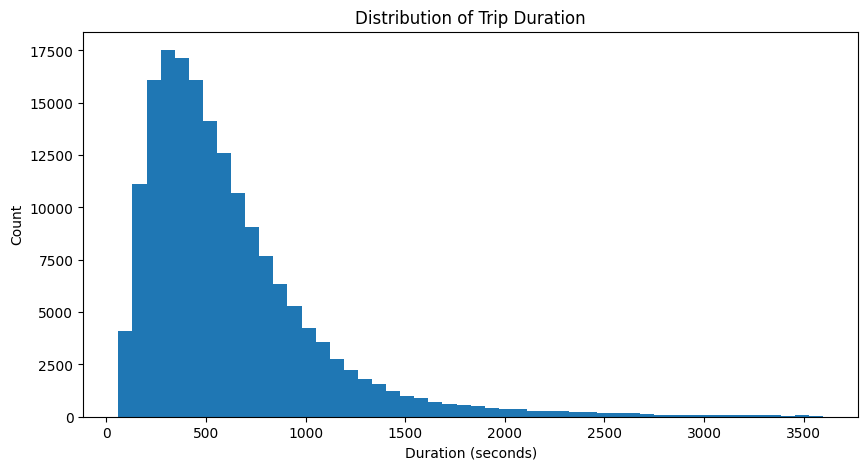

```python
plot_histogram(df, 'duration_sec', title='Distribution of Trip Duration', xlabel='Duration (seconds)')
```

> Trip duration shows a strong right-skewed distribution, with most trips being short (under ~1000 seconds) and a long tail of fewer, longer trips. This indicates that the majority of users take quick rides, while extended trips are less common.

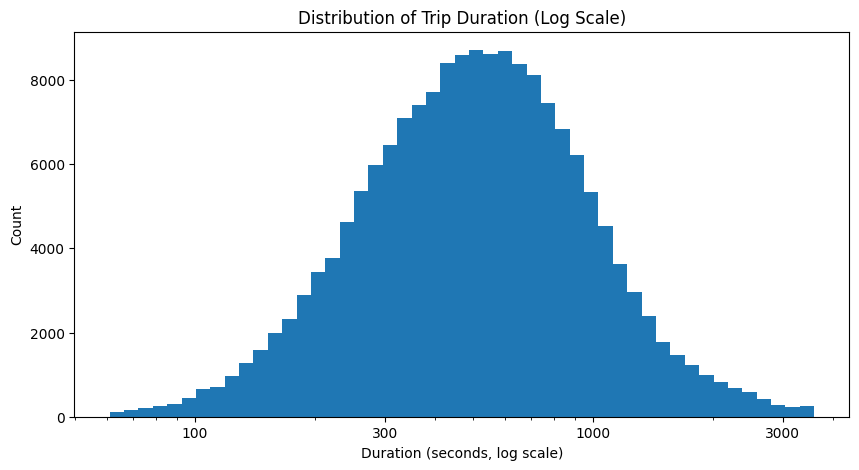

```python
# same plot but here i add different xlabel operation with log
plt.figure(figsize=(10,5))

bins = np.logspace(np.log10(df['duration_sec'].min()), np.log10(df['duration_sec'].max()), 50)

plt.hist(df['duration_sec'], bins=bins)
plt.xscale('log')
plt.xticks([100, 300, 1000, 3000],['100', '300', '1000', '3000'])
plt.title('Distribution of Trip Duration (Log Scale)')
plt.xlabel('Duration (seconds, log scale)')
plt.ylabel('Count')
plt.show()
```

> After applying a log transformation, the distribution of trip duration becomes more symmetric and easier to interpret. Most trips are concentrated within a moderate duration range, while very short and very long trips are less frequent. The transformation helps reveal the underlying structure of the data more clearly by reducing the effect of extreme values.

### Question 2: What are the most popular periods to ride a bike?

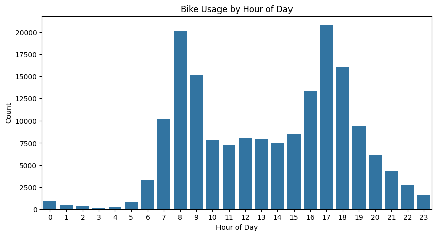

```python
def plot_count(data, column, title='', xlabel='', rotation=0):
    plt.figure(figsize=(10,5))
    sns.countplot(data=data, x=column)
    plt.title(title)
    plt.xlabel(xlabel)
    plt.ylabel('Count')
    plt.xticks(rotation=rotation)
    plt.show()

plot_count(df, 'start_hour', title='Bike Usage by Hour of Day', xlabel='Hour of Day')
```

> Bike usage peaks during morning (around 8 AM) and evening (around 5–6 PM) hours, indicating strong commuting behavior. Usage is lowest during late night and early morning hours.

### Question 3: Which days are most crowded for riding bikes?

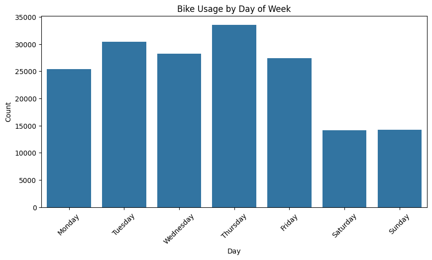

```python
# order days correctly
day_order = ['Monday','Tuesday','Wednesday','Thursday','Friday','Saturday','Sunday']

plt.figure(figsize=(10,5))
sns.countplot(data=df, x='start_day', order=day_order)
plt.title('Bike Usage by Day of Week')
plt.xlabel('Day')
plt.ylabel('Count')
plt.xticks(rotation=45)
plt.show()
```

> Bike usage is higher on weekdays, especially midweek, and lower on weekends. This suggests that the system is primarily used for commuting rather than leisure.

### Question 4: How are the different kind of users distributed (customer vs. subscriber)?

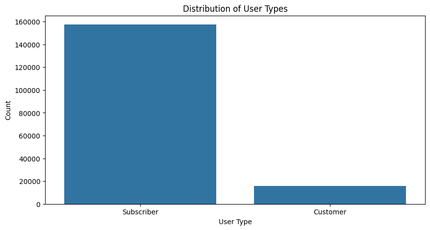

```python
plot_count(df, 'user_type', title='Distribution of User Types', xlabel='User Type')
```

> Most users are Subscribers, while Customers represent a much smaller portion. This indicates that the majority of users are regular riders rather than occasional users.

#### Discuss the distribution(s) of your variable(s) of interest. Were there any unusual points? Did you need to perform any transformations?

> Trip duration is right-skewed, with most trips being short and a few long outliers. A log transformation was applied to better visualize the distribution and reduce skewness.

#### Of the features you investigated, were there any unusual distributions? Did you perform any operations on the data to tidy, adjust, or change the form of the data? If so, why did you do this?

> Some variables were imbalanced (e.g., more Subscribers than Customers), and trip duration had extreme values. Data cleaning included handling missing values, removing outliers, and creating new features like age and time variables for better analysis.

## Bivariate Exploration

### Question 5: How does the length of a trip vary depending on the time of day?

```python
def plot_box(data, x, y, title='', xlabel='', ylabel=''):
    plt.figure(figsize=(10,5))
    sns.boxplot(data=data, x=x, y=y)
    plt.title(title)
    plt.xlabel(xlabel)
    plt.ylabel(ylabel)
    plt.show()
```

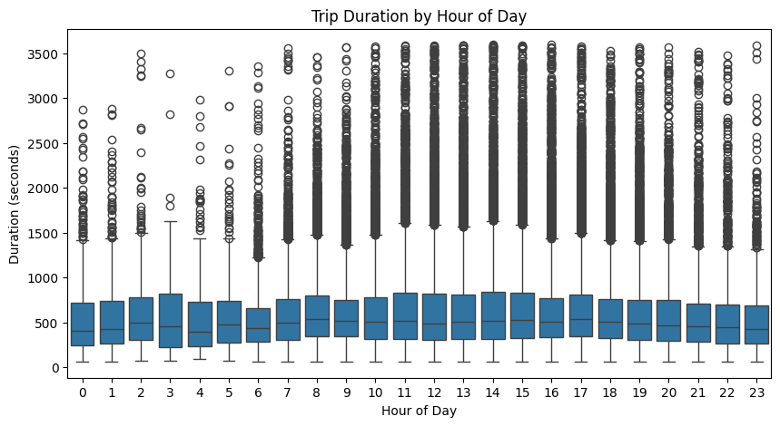

```python
plot_box(df, 'start_hour', 'duration_sec', title='Trip Duration by Hour of Day',
         xlabel='Hour of Day',
         ylabel='Duration (seconds)')
```

### Question 6: Does the length of a trip correlate with the user's age?

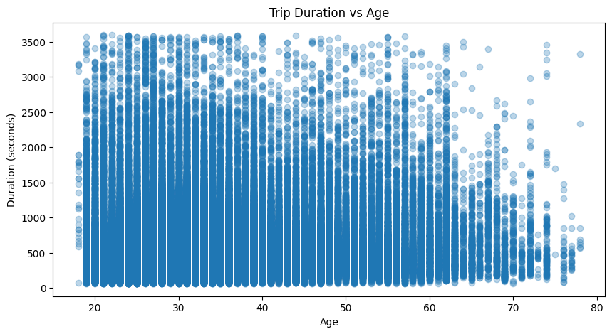

```python
def plot_scatter(data, x, y, title='', xlabel='', ylabel=''):
    plt.figure(figsize=(10,5))
    plt.scatter(data[x], data[y], alpha=0.3)
    plt.title(title)
    plt.xlabel(xlabel)
    plt.ylabel(ylabel)
    plt.show()

plot_scatter(df, 'age', 'duration_sec', title='Trip Duration vs Age', xlabel='Age', ylabel='Duration (seconds)')
```

> There is no strong relationship between age and trip duration. Most users, regardless of age, take trips of similar duration. While there is some variability, age does not appear to significantly influence how long trips last.

### Question 7: How does trip duration differ between Subscribers and Customers?

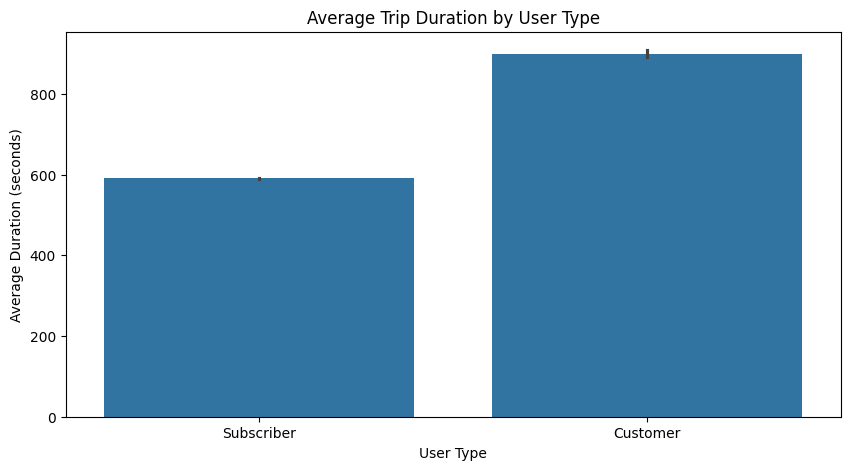

```python
plt.figure(figsize=(10,5))

sns.barplot(data=df,
            x='user_type',
            y='duration_sec',
            estimator=np.mean)

plt.title('Average Trip Duration by User Type')
plt.xlabel('User Type')
plt.ylabel('Average Duration (seconds)')

plt.show()
```

> Customers have a significantly higher average trip duration than Subscribers. This suggests that Customers tend to use bikes for longer, more leisure-oriented trips, while Subscribers likely use bikes for shorter, routine commuting purposes.

#### Talk about some of the relationships you observed in this part of the investigation. How did the feature(s) of interest vary with other features in the dataset?

> Trip duration shows a clear difference across user types, where Customers have significantly longer average trip durations compared to Subscribers. Trip duration also varies slightly by hour of day, with moderate fluctuations and slightly higher durations during mid-day hours, while early morning and late hours tend to have shorter trips. In contrast, age does not show a strong relationship with trip duration, as durations appear widely distributed across all age values without a clear trend.

#### Did you observe any interesting relationships between the other features (not the main feature(s) of interest)?

> An interesting relationship is observed between user type and trip duration, where Customers consistently have longer trips than Subscribers. Additionally, the variation of trip duration across hours suggests that time of day influences ride behavior, but this effect is less pronounced compared to the impact of user type. Overall, user type appears to be the strongest factor influencing trip duration, while age and time of day play a more moderate role.

## Multivariate Exploration

### Question 8: What interactions exist between various parameters (such as user type and time of day) that affect journey duration?

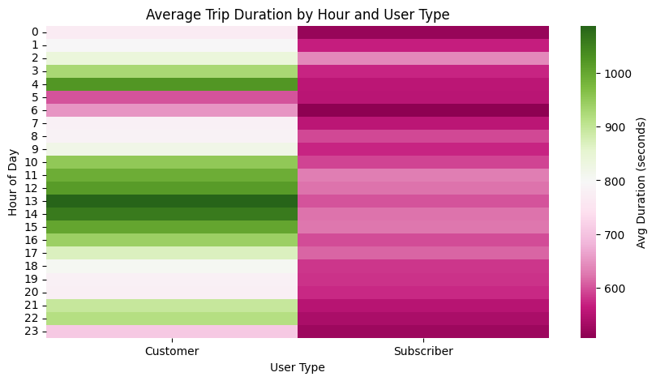

```python
# create pivot table
heat_data = df.groupby(['start_hour', 'user_type'])['duration_sec'].mean().reset_index()
heat_data = heat_data.pivot(index='start_hour', columns='user_type', values='duration_sec')

plt.figure(figsize=(10,5))
sns.heatmap(
    heat_data,
    cmap='PiYG',
    cbar_kws={'label': 'Avg Duration (seconds)'}
)
plt.title('Average Trip Duration by Hour and User Type')
plt.xlabel('User Type')
plt.ylabel('Hour of Day')
plt.show()
```

> Trip duration is influenced by both user type and time of day. Customers generally have longer trip durations across most hours, while Subscribers tend to have shorter and more consistent trips, especially during peak commuting times. This indicates that Subscribers primarily use the service for regular commuting, whereas Customers are more likely to take longer, less time-dependent trips.

### Question 9: How does the length of a trip change depending on the time of day for various user types?

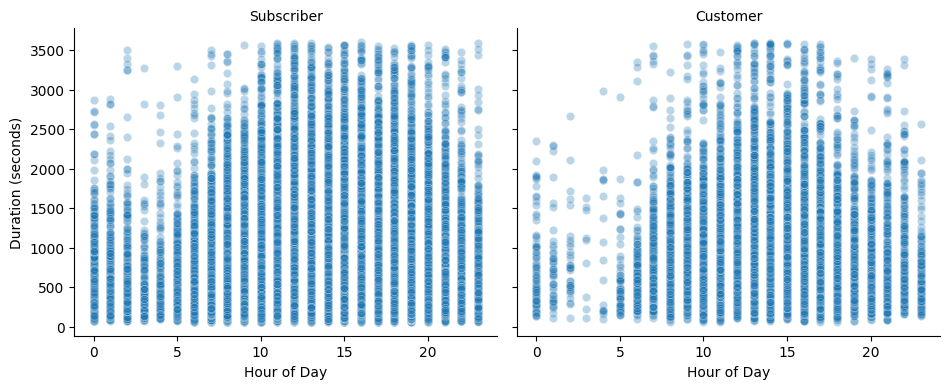

```python
g = sns.FacetGrid(df, col='user_type', height=4, aspect=1.2)

g.map(sns.scatterplot, 'start_hour', 'duration_sec', alpha=0.3)

g.set_axis_labels('Hour of Day', 'Duration (seconds)')
g.set_titles('{col_name}')

plt.show()
```

> When examining both user type and time of day, distinct behavioral patterns emerge. Subscribers show more concentrated activity during typical commuting hours, with shorter and more consistent trip durations. In contrast, Customers display greater variability in trip duration across all hours and tend to have longer trips overall. This suggests that Subscribers primarily use the service for routine commuting, while Customers use it more flexibly throughout the day.

### Question 10: What differences exist between user types in the link between age and trip duration?

```python
df.loc[:, 'age_group'] = pd.cut(df['age'],
                               bins=[0,10,20,30,40,50,60,70,80],
                               labels=['0-10','10-20','20-30','30-40','40-50','50-60','60-70','70-80'])
```

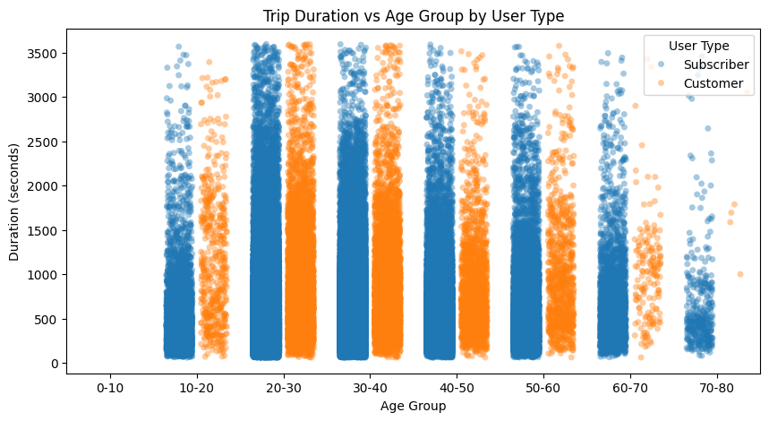

```python
plt.figure(figsize=(10,5))

sns.stripplot(data=df,
              x='age_group',
              y='duration_sec',
              hue='user_type',
              jitter=0.3,
              dodge=True,
              alpha=0.4)         # separates user types

plt.title('Trip Duration vs Age Group by User Type')
plt.xlabel('Age Group')
plt.ylabel('Duration (seconds)')
plt.legend(title='User Type')

plt.show()
```

> There is no strong relationship between age and trip duration for either user group. However, when user type is considered, Customers consistently exhibit longer trip durations across most age groups, while Subscribers maintain shorter and more uniform trip durations. This indicates that user type has a stronger influence on trip duration than age.

### Question 11: What is the relationship between average trip duration and user type and time of day?

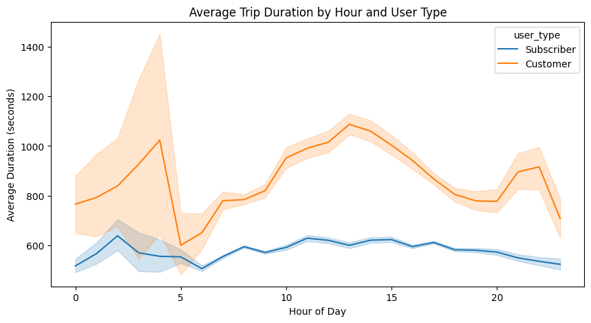

```python
plt.figure(figsize=(10,5))

sns.lineplot(data=df, x='start_hour', y='duration_sec', hue='user_type', estimator='mean')

plt.title('Average Trip Duration by Hour and User Type')
plt.xlabel('Hour of Day')
plt.ylabel('Average Duration (seconds)')

plt.show()
```

> The combined effect of user type and time of day reveals clear differences in trip duration patterns. Customers consistently have higher average trip durations throughout the day, with noticeable peaks during midday and afternoon hours. Subscribers, on the other hand, show relatively stable and lower average trip durations, particularly during peak commuting times. This highlights that Customers tend to take longer, more flexible trips, while Subscribers exhibit more structured and time-efficient travel behavior.

#### Talk about some of the relationships you observed in this part of the investigation. Were there features that strengthened each other in terms of looking at your feature(s) of interest?

> Trip duration is influenced by both time of day and user type together. The heatmap clearly shows that Customers consistently have longer average trip durations across all hours, while Subscribers have shorter and more stable trips.The effect of time of day is more visible for Customers, where trip durations peak around mid-day and early afternoon. In contrast, Subscribers maintain relatively consistent durations throughout the day.This indicates that user type and time of day together strengthen the understanding of trip duration patterns, especially highlighting different usage behaviors.

#### Were there any interesting or surprising interactions between features?

> A key interaction is that even during all hours of the day, Customers consistently have longer trips than Subscribers, as clearly shown in the heatmap and line plot. Additionally, time of day impacts Customers more strongly, with noticeable increases in duration during mid-day hours, while Subscribers remain stable. This suggests that user type is the dominant factor, but its interaction with time of day reveals different behavioral patterns. Overall, the combination of user type and time of day provides deeper insight than either variable alone.

## Conclusions

### Reflection on Data Exploration

The analysis followed a structured approach, starting with univariate exploration to understand individual variable distributions, followed by bivariate analysis to examine relationships, and finally multivariate analysis to uncover deeper interactions between variables.

Data cleaning steps such as handling missing values, removing outliers, and creating new features (e.g., age and time-based variables) were essential in improving the quality and interpretability of the analysis. Additionally, applying a log transformation to trip duration helped better visualize its distribution.

Overall, the step-by-step exploration allowed for a clear understanding of user behavior and usage patterns within the bike-sharing system.